# Advertisement CTR Prediction

The Advertisement CTR Prediction challenge is to predict the Click-Through Rate (CTR) for advertisements using the dataset 2020-digix-advertisement-ctr-prediction.

The objective of this Jupyter Notebook is to do an Exploratory Data Analysis over the sampling dataset exported in `01-SamplingDataset.ipynb`.

## Imports

```python
# Append local development on system path
import sys
sys.path.append('../../')

# Data Manipulation
from src.data.build_data import load_data, reduce_mem_usage
import pandas as pd
import numpy as np

# Data Visualization
from src.utils import custom_plot
import matplotlib.pyplot as plt
import seaborn as sns

# Others
import os
```

## Load dataset

```python
# Set dataset path
dataset_path = '../../data/processed/train_data.csv'
```

```python
dataset_df = load_data(dataset_path)
```

```
1it [00:01,  1.70s/it]
```

# Exploratory Data Analysis (EDA)

```python
dataset_df.shape
```

```
(838143, 36)
```

```python
dataset_df.info(memory_usage=True)
```

```
<class 'pandas.core.frame.DataFrame'>
RangeIndex: 838143 entries, 0 to 838142
Data columns (total 36 columns):
 #   Column                       Non-Null Count   Dtype
---  ------                       --------------   -----
 0   label                        838143 non-null  int8
 1   uid                          838143 non-null  int32
 2   task_id                      838143 non-null  int16
 3   adv_id                       838143 non-null  int16
 4   creat_type_cd                838143 non-null  int8
 5   adv_prim_id                  838143 non-null  uint8
 6   dev_id                       838143 non-null  int8
 7   inter_type_cd                838143 non-null  int8
 8   slot_id                      838143 non-null  int8
 9   spread_app_id                838143 non-null  int8
```

[output cut: 28 more lines]

## Number of Missing Values

As we can see below, there is not missing values in the provided dataset.

```python
dataset_df.isna().sum().sum()
```

```
0
```

## Number of Duplicates Rows

As we can see below, there is 4.527 duplicated rows, i.e, the values for all columns are the same.

As the number of duplicated rows represents 0.5% of the samples in provided dataset and only 2.34% of samples when users click on ad, the duplicated rows will be delete from dataset.

```python
duplicated_rows_df = dataset_df.duplicated().value_counts().reset_index(name='count')
duplicated_rows_df.rename(columns={'index': 'is_duplicated'}, inplace=True)

duplicated_rows_df['percentage'] = duplicated_rows_df['count'] / dataset_df.shape[0]
duplicated_rows_df
```

|  | is_duplicated | count | percentage |
| --- | --- | --- | --- |
| 0 | False | 833616 | 0.994599 |
| 1 | True | 4527 | 0.005401 |

```python
duplicated_rows_label_df = dataset_df.loc[dataset_df.duplicated(), 'label'].value_counts().reset_index(name='count')

duplicated_rows_label_df['percentage'] = duplicated_rows_label_df['count'] / duplicated_rows_label_df['count'].sum()
duplicated_rows_label_df
```

|  | label | count | percentage |
| --- | --- | --- | --- |
| 0 | 0 | 4421 | 0.976585 |
| 1 | 1 | 106 | 0.023415 |

```python
# Drop duplicated rows
dataset_df.drop_duplicates(inplace=True)
dataset_df.shape
```

```
(833616, 36)
```

## Unique Values

Using the information below we can see:

- There are 395.465 users in the provided dataset.
- 69 apps were used to collect the click-through rate.
- The ads were displayed in 4 differents ways.

Some columns like `creat_type_cd`, `inter_type_cd`, `app_first_class`, `city_rank`, `career`, `gender`, `net_type`, and others there are few values.

```python
dataset_df.nunique()
```

```
label                               2
uid                            395465
task_id                          3622
adv_id                           4206
creat_type_cd                       8
adv_prim_id                       101
dev_id                             55
inter_type_cd                       4
slot_id                            12
spread_app_id                      69
tags                               30
app_first_class                     3
app_second_class                   19
age                                 8
city                              344
city_rank                           4
device_name                        87
device_size                       142
career                              9
gender                              3
net_type                            5
residence                          36
his_app_size                       21
his_on_shelf_time                   4
app_score                           2
emui_dev                           16
list_time                          16
device_price                        8
up_life_duration                   21
up_membership_grade                 4
membership_life_duration           11
consume_purchase                    9
communication_onlinerate          861
communication_avgonline_30d        14
indu_name                          38
pt_d                                7
dtype: int64
```

## Distribution of Label column

The provided data is categorized as an unbalanced dataset, i.e., there are a lot of samples belongs to `label = 0` and few examples belongs to `label = 1`.

```python
ctr_distribution_df = dataset_df['label'].value_counts().reset_index(name='count')
ctr_distribution_df.rename(columns={'label': 'click_through_indicator'}, inplace=True)

ctr_distribution_df['percentage'] = ctr_distribution_df['count'] / dataset_df.shape[0]
```

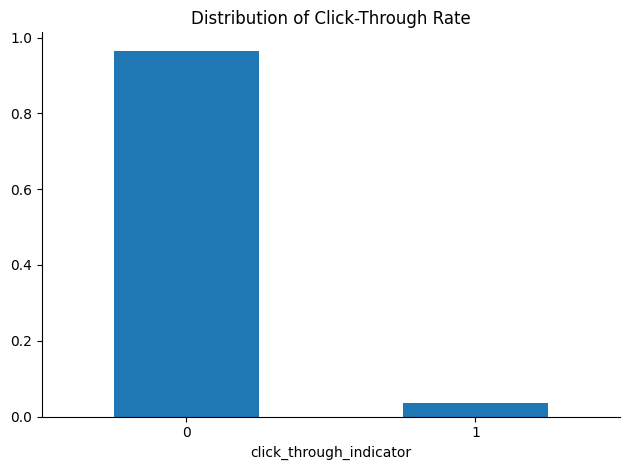

```python
ctr_ax = ctr_distribution_df.plot(kind='bar', x='click_through_indicator', y='percentage', rot=0, legend=False, title='Distribution of Click-Through Rate')
custom_plot(ctr_ax)

plt.tight_layout()
```

### As our focus is predict when an user will click on an advertisement we will analysis the columns' impact regards when users did a click.

```python
clicked_mask = (dataset_df['label'] == 1).values
```

## Segment Analysis

#### In the graph below the users who belongs to groups 4, 5, 6 and 7 in age columns had the most clicks in ads than users who belongs to groups -1, 1, 2 and 3.

#### This behaviour follow the age column distribution in the whole dataset.

```python
age_df = dataset_df['age'].value_counts().reset_index(name='count')
age_df['percentage'] = age_df['count'] / age_df['count'].sum()

users_age_df = dataset_df.loc[clicked_mask, ['age']].value_counts().reset_index(name='n_clicks')
users_age_df['percentage'] = users_age_df['n_clicks'] / clicked_mask.sum()
```

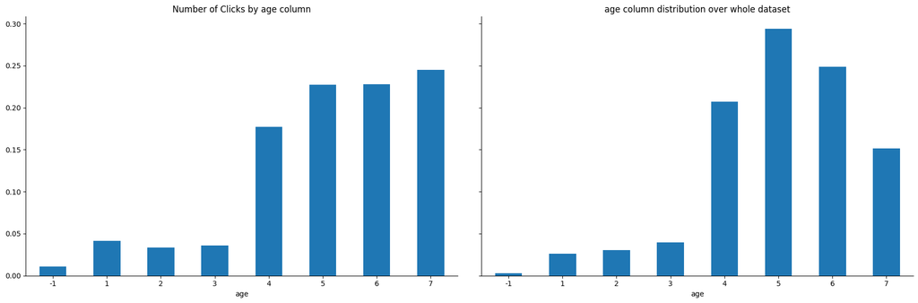

```python
fig, (axs1, axs2) = plt.subplots(1, 2, figsize=(18, 6), sharey=True)

clicks_age_ax = users_age_df.sort_values('age').plot(kind='bar', x='age', y='percentage', ax=axs1, title='Number of Clicks by age column', rot=0, legend=False)
custom_plot(clicks_age_ax)

age_ax = age_df.sort_values('age').plot(kind='bar', x='age', y='percentage', ax=axs2, title='age column distribution over whole dataset', rot=0, legend=False)
custom_plot(age_ax)

plt.tight_layout(w_pad=3)
```

### Gender equals 3 had few records in the dataset. It might suggest an option like "Others"

```python
gender_df = dataset_df['gender'].value_counts().reset_index(name='count')
gender_df['percentage'] = gender_df['count'] / gender_df['count'].sum()

users_gender_df = dataset_df.loc[clicked_mask, 'gender'].value_counts().reset_index(name='n_clicks')
users_gender_df['percentage'] = users_gender_df['n_clicks'] / clicked_mask.sum()
```

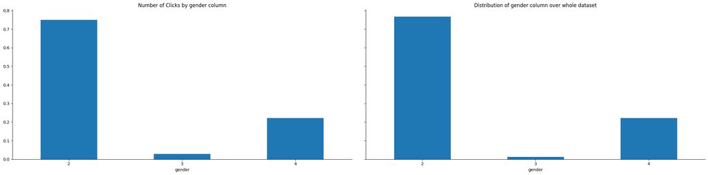

```python
fig, (axs1, axs2) = plt.subplots(1, 2, figsize=(24, 6), sharey=True)

clicks_gender_ax = users_gender_df.sort_values('gender').plot(kind='bar', x='gender', y='percentage', ax=axs1, title='Number of Clicks by gender column', rot=0, legend=False)
custom_plot(clicks_gender_ax)

gender_ax = gender_df.sort_values('gender').plot(kind='bar', x='gender', y='percentage', ax=axs2, title='Distribution of gender column over whole dataset', rot=0, legend=False)
custom_plot(gender_ax)

plt.tight_layout(w_pad=3)
```

### Users who belongs to groups 9 and 4 of career and lives in cities of city_rank equals to 3 had the most clicks in ads.

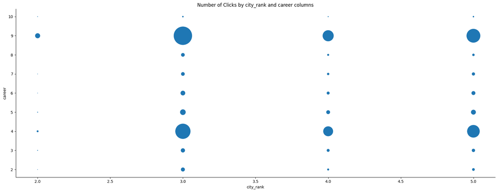

```python
users_city_rank_career_df = dataset_df.loc[clicked_mask, ['city_rank', 'career']].groupby('city_rank')['career'].value_counts().reset_index(name='n_clicks')
users_city_rank_career_df['size'] = users_city_rank_career_df['n_clicks'] * 0.3

axs = users_city_rank_career_df.plot(kind='scatter', x='city_rank', y='career', s='size', title='Number of Clicks by city_rank and career columns', figsize=(18, 7))
custom_plot(axs)

plt.tight_layout()
```

### The number of clicks has a well skew between the pt_d values. But, we can see that in the first day (pt_d equals to 1) the users haev the most number of clicks.

```python
users_first_day_df = dataset_df.groupby('uid')['pt_d'].min().reset_index(name='first_day')

dataset_df = dataset_df.merge(users_first_day_df, on='uid', how='left')
dataset_df['is_first_day'] = dataset_df['pt_d'] == dataset_df['first_day']

users_date_clicks_df = dataset_df.loc[clicked_mask, 'pt_d'].value_counts().sort_index().reset_index(name='n_clicks')
users_first_day_clicks_df = dataset_df.loc[clicked_mask, 'is_first_day'].value_counts().reset_index(name='n_clicks')
```

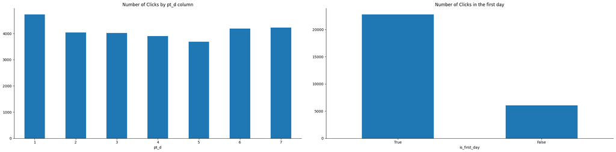

```python
fig, (axs1, axs2) = plt.subplots(1, 2, figsize=(24, 6))

clicks_pt_d_ax = users_date_clicks_df.sort_values('pt_d').plot(kind='bar', x='pt_d', y='n_clicks', ax=axs1, title='Number of Clicks by pt_d column', rot=0, legend=False)
custom_plot(clicks_pt_d_ax)

clicks_first_day_ax = users_first_day_clicks_df.plot(kind='bar', x='is_first_day', y='n_clicks', ax=axs2, title='Number of Clicks in the first day', rot=0, legend=False)
custom_plot(clicks_first_day_ax)

plt.tight_layout(w_pad=3)
```

## Segment Analysis: Impact of City

In the graph `Average Number of Clicks by Users` we can see that cities that belongs to city_rank equals to 2 had the most average number os clicks by users.

However, in the graph `Average Number of Clicks by Apps` the sames group of cities (city_rank equals to 2) had the smaller average number of clicks by apps.

```python
n_users_by_city = dataset_df.groupby(['city'])['uid'].nunique().reset_index(name='n_users')
n_apps_by_city = dataset_df.groupby(['city'])['spread_app_id'].nunique().reset_index(name='n_apps')
n_ctr_by_city = dataset_df[clicked_mask].groupby('city')['label'].count().reset_index(name='n_clicks')
```

```python
city_stats = dataset_df[['city', 'city_rank']].drop_duplicates()
city_stats = city_stats.merge(n_users_by_city, on='city', how='left')
city_stats = city_stats.merge(n_apps_by_city, on='city', how='left')
city_stats = city_stats.merge(n_ctr_by_city, on='city', how='left')

city_stats['clicks_per_users'] = city_stats['n_clicks'] / city_stats['n_users']
city_stats['clicks_per_apps'] = city_stats['n_clicks'] / city_stats['n_apps']
```

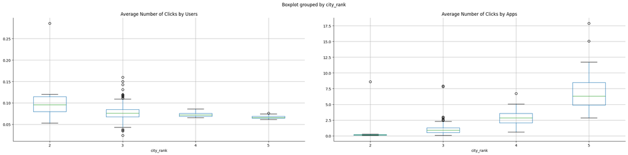

```python
fig, (axs1, axs2) = plt.subplots(1, 2, figsize=(24, 6))

clicks_city_rank_users_ax = city_stats.boxplot(by='city_rank', column='clicks_per_users', ax=axs1, rot=0)
clicks_city_rank_users_ax.set_title('Average Number of Clicks by Users')
custom_plot(clicks_city_rank_users_ax)

clicks_city_rank_apps_ax = city_stats.boxplot(by='city_rank', column='clicks_per_apps', ax=axs2, rot=0)
clicks_city_rank_apps_ax.set_title('Average Number of Clicks by Apps')
custom_plot(clicks_city_rank_apps_ax)

plt.tight_layout(w_pad=5)
```

## Correlation Matrix

In the matrix below we can infer that:

- App tag of an ad task (tags) has a stronger positive relation to display form of an ad material (inter_type_cd) - It might suggest that some ad forms are better than others for specific apps
- App tag of an ad task (tags) has a stronger positive relation to app rating score (app_score) - It might suggest with which ad tasks are used by the more popular apps.

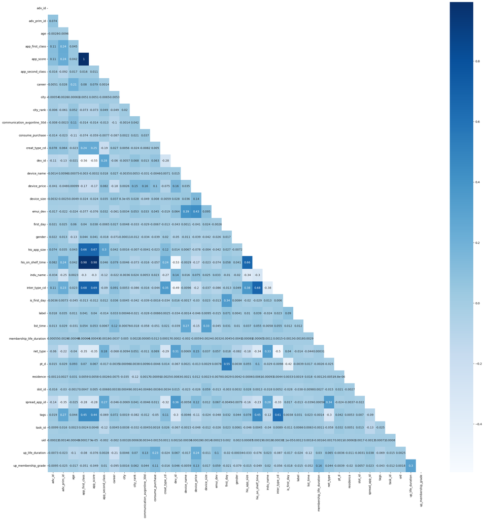

```python
plt.figure(figsize=(30, 30))

corr_matrix = dataset_df[dataset_df.columns.difference(['communication_onlinerate'])].corr()

mask = np.zeros_like(corr_matrix)
mask[np.triu_indices_from(mask)] = True

corr_heatmap = sns.heatmap(corr_matrix, cmap="Blues", annot=True, mask=mask)
```

# Feature Engineering

As the values in dataset are encoded it is very complicated apply a feature engineering process.

```python
from sklearn.preprocessing import OneHotEncoder
```

```python
one = OneHotEncoder(sparse_output=False, handle_unknown='ignore')
communication_onlinerate_encoded = one.fit_transform(dataset_df['communication_onlinerate'].values.reshape(-1, 1))
```

```python
n_columns = communication_onlinerate_encoded.shape[1]
columns = [f"communication_onlinerate_{str(i).zfill(4)}" for i in range(n_columns)]

communication_onlinerate_encoded_df = pd.DataFrame(communication_onlinerate_encoded, columns=columns, dtype=np.uint8)
```

```python
dataset_df = dataset_df.join(communication_onlinerate_encoded_df)
```

```python
dataset_df.drop(columns=['communication_onlinerate'], inplace=True)
```

## Export the dataset

```python
os.makedirs('../../data/processed/', exist_ok=True)
dataset_df.to_csv('../../data/processed/eda_train_data.csv', index=False, encoding='utf-8')
```